# Dynamics of Neural Systems: Exercise Sheet 5

## Simulation of multi-compartment HH model

According to the Kirchhoffs law it must hold that the currents of a compartment $j$ and adjoining compartments $j-1$ and $j+1$ sum up to zero : $0 = I_{j-1} + I_j + I_{j+1}$. Within a compartment $j$ four different currents can be measured . One caused by the capacitor ($C_m \frac{dV'}{dt}$), two caused by the Ion flux of Na and K ($g_{Na,j}(V_j - E_{Na}),g_{K,j}(V_j - E_{K})$) , one caused by leakage ($g_{L}(V_j - E_{L})$)and one potential externel input current $I_e(t)$. Using Kichhoffs current law again you can say that the current of compartment $j$ can be written by: $I_j= C_m \frac{dV}{dt} + g_{L}(V_j - E_{L}) + g_{Na,j}(V_j - E_{Na}) + g_{K,j}(V_j - E_{K}) - I_e(t)$. The currents flowing from adjoining compartments into compartment $j$ can be written by: $I_{j-1} = g_{ax}(V_j - V_{j-1})$ and $I_{j+1} = g_{ax}(V_j - V_{j+1})$. Plugging all together gives us the DEQ:

$$ 0 = C_m \frac{dV}{dt} + g_{L}(V_j - E_{L}) + g_{Na,j}(V_j - E_{Na}) + g_{K,j}(V_j - E_{K}) - I_e(t) + g_{ax}(V_j - V_{j-1}) + g_{ax}(V_j - V_{j+1}) \\ C_m \frac{dV}{dt} = I_e(t) - g_{L}(V_j - E_{L}) - g_{Na,j}(V_j - E_{Na}) - g_{K,j}(V_j - E_{K}) - g_{ax}(V_j - V_{j-1}) - g_{ax}(V_j - V_{j+1}) \\ \frac{dV}{dt} = \frac{I_e(t) - g_{L}(V_j - E_{L}) - g_{Na,j}(V_j - E_{Na}) - g_{K,j}(V_j - E_{K}) - g_{ax}(V_j - V_{j-1}) - g_{ax}(V_j - V_{j+1})}{C_m}$$

with: $g_{Na,j} = \hat{g}_{Na}m_j^3h_j$, $g_{K,j} = \hat{g}_{K}n_j^4$ and the DEQ:

$$\frac{dm}{dt} = \alpha_m(V(j,t)) (1-m) - \beta_m(V(j,t))m \\ \frac{dh}{dt} = \alpha_h(V(j,t)) (1-h) - \beta_h(V(j,t))h \\ \frac{dn}{dt} = \alpha_m(V(j,t)) (1-n) - \beta_n(V(j,t))n$$

In order to derive the voltage at compartment j at time t you can approximate all voltage dependend conductances in this compartment at time t using forward euler method.

$$ m_j(t + \Delta t) = m_j(t) + \Delta t \cdot \frac{dm_j}{dt} \\ h_j(t + \Delta t) = h_j(t) + \Delta t \cdot \frac{dh_j}{dt} \\ n_j(t + \Delta t) = n_j(t) + \Delta t \cdot \frac{dn_j}{dt} \\ g_{Na,j,t} = \hat{g}_{Na}m_j(t)^3h_j(t) \\ g_{K,j,t} = \hat{g}_{K}n_j(t)^4$$

Having approximated these conductances you can derive V(j,t) by using forward euler with:

$$ V(j,t+\Delta t) = V(j,t) + \Delta t \cdot \frac{dV}{dt}$$

```python
%matplotlib notebook
import math
import numpy as np
import matplotlib.pyplot as plt
from mpl_toolkits.mplot3d import Axes3D
```

### electrical and geometrical properties

```python
C_m = 1 # μF, membrane capacitance.
E_Na = 115 # mV , sodium equilibrium potential.
E_K = -12 # mV , potassium equilibrium potential.
E_L = 10.6 # mV , leak equilibrium potential.
V_0 = 0 # mV , (starting and) membrane equilibrium potential.
g_Na = 120 # mS, maximum conductance for sodium channel.
g_K = 36 # mS, maximum conductance for potassium channel.
g_L = 0.3 # mS, leak conductance.
g_ax = 0.5 # mS, axial conductance.
N = 100 # number of compartments.
delta_t = 0.025 # ms
```

### Hodgkin-Huxley (HH) formulars

```python
def dV_dt(V_i,V_j,V_k,input_function, m, h, n, j, t):

    current_V = input_function(j,t) - g_L*(V_j - E_L) - conductance_Na(m,h) * (V_j - E_Na) - conductance_K(n) * (V_j - E_K)
    prev_V = g_ax*(V_j - V_i)
    next_V = g_ax*(V_j - V_k)

    return (current_V - prev_V -  next_V)/C_m

# ------------------------------------------------ Conductances -------------------------------------------------------
def conductance_Na(m,h):
    return g_Na* (m ** 3) * h


def conductance_K(n):
    return g_K* (n**4)


# ------------------------------------------- Gatinng Probabilities ---------------------------------------------------
def gating(V,alpha,beta,gate_var):
    return alpha(V) * (1 - gate_var) - beta(V) * gate_var


# ----------- Sodium channels -----------------------------------------------------------------------------------------
def alpha_m(V):
    if(V != 25):
        return 0.1 * (V - 25)/ (1 - math.exp(-(V - 25)/10))
    if(V == 25):
        return 1

def beta_m(V):
    return 4* math.exp(-(V/18))



def alpha_h(V):
    return 0.07*math.exp(-V/20)

def beta_h(V):
    return 1/(1 + math.exp(-(V-30)/10))



def dm_dt(V, current_m):
    return gating(V, alpha_m, beta_m, current_m)

def dh_dt(V,current_h):
     return gating(V, alpha_h, beta_h, current_h)



# ----------- Potassium channels --------------------------------------------------------------------------------------
def alpha_n(V):
    if(V != 10):
        return 0.01* (V - 10)/(1 - math.exp(-(V-10)/10))
    if(V == 10):
        return 0.1


def beta_n(V):
    return 0.125*math.exp(-V/80)


def dn_dt(V,current_n):
    return gating(V, alpha_n, beta_n, current_n)
```

### Approximate Model

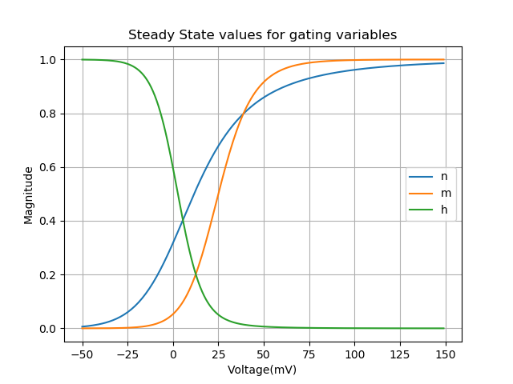

```python
j_e = 14
t_e = 60 # ms
t_s = 260 # ms
I_0 = [6, 8, 15, 20] # muA

def create_rectangle_impulse(I):
    def rectangle_impulse(j,t):
        if((t < t_e) or (t_s <= t) or (j != j_e)):
            return 0
        if((t_e <= t < t_s) and (j == j_e)):
            return I
    return rectangle_impulse


def steady_state(V_0):
    time = np.arange(0,500,0.025)
    n = np.zeros(1)
    m = np.zeros(1)
    h = np.zeros(1)

    for t in time:
        n_old = n[0]
        delta_n = dn_dt(V_0,n_old)
        n_new = n_old + delta_t * delta_n
        n[0] = n_new

        m_old = m[0]
        delta_m = dm_dt(V_0, m_old)
        m_new = m_old + delta_t * delta_m
        m[0] = m_new

        h_old = h[0]
        delta_h = dh_dt(V_0, h_old)
        h_new = h_old + delta_t * delta_h
        h[0] = h_new

    return m[0],h[0],n[0]

# Debugging
n_stat = np.zeros(200)
m_stat = np.zeros(200)
h_stat = np.zeros(200)
voltage = range(-50,150)
for i,v in enumerate(voltage):
    m_stat[i],h_stat[i],n_stat[i] = steady_state(v)

fig, ax = plt.subplots()
ax.plot(voltage, n_stat, label = "n")
ax.plot(voltage, m_stat, label = "m")
ax.plot(voltage, h_stat, label = "h")
ax.legend()
ax.set(xlabel='Voltage(mV)', ylabel='Magnitude',title='Steady State values for gating variables')

ax.grid()
plt.show()
```

```python
def approximate_model(N, V_0, input_function, duration, delta_t):
    m_0,h_0,n_0 = steady_state(V_0)
    steps = np.arange(0,duration,delta_t)


    V = np.zeros((N+2, steps.shape[0]))
    m = np.zeros((N+2, steps.shape[0]))
    h = np.zeros((N+2, steps.shape[0]))
    n = np.zeros((N+2, steps.shape[0]))

    V[0:N+2,0] = [V_0 for i in range(N+2)]
    m[0:N+2,0] = [m_0 for i in range(N+2)]
    h[0:N+2,0] = [h_0 for i in range(N+2)]
    n[0:N+2,0] = [n_0 for i in range(N+2)]



    for i,t in enumerate(steps[:-1]):
        for j in range(1,N+1):
            V_old = V[j,i]
            m_old = m[j,i]
            h_old = h[j,i]
            n_old = n[j,i]



            delta_m = dm_dt(V_old, m_old)
            m_new = m_old + delta_t * delta_m
            m[j,i+1] = m_new

            delta_h = dh_dt(V_old, h_old)
            h_new = h_old + delta_t * delta_h
            h[j,i+1] = h_new

            delta_n = dn_dt(V_old, n_old)
            n_new = n_old + delta_t * delta_n
            n[j,i+1] = n_new


            delta_V = dV_dt(V[j-1,i],V_old,V[j+1,i],input_function, m_old, h_old, n_old, j, t)
            V_new = V_old + delta_t * delta_V
            V[j,i+1] = V_new

        V[0,i+1] = V[1,i+1]



    return V,m,h,n,steps
```

[figure not shown]

```python
rectangle_impulse = create_rectangle_impulse(I_0[3])
V,m,h,n, steps = approximate_model(N, V_0, rectangle_impulse, 500, delta_t)


x = [i for i in steps]
y = range(1,N+2)
X, Y = np.meshgrid(x, y)


fig = plt.figure()
ax = fig.add_subplot(111, projection='3d')
ax.plot_surface(X, Y, V[1:N+2,:],rstride=1, cstride=1, cmap='viridis')

ax.set_xlabel('time (ms)')
ax.set_ylabel('Compartments')
ax.set_zlabel('\n\n MembranPotential (mV)')


ax.zaxis._axinfo['label']['space_factor'] = 5
ax.text2D(0.05, 0.95, "Multi Compartment Simulation (Rectangle Current: %s μA)" % I_0[3], transform=ax.transAxes)
ax.view_init(40, -70)

####################
##### Top View #####
####################

#ax.view_init(0,-90)

#ax.set_zticks([])
#ax.set_zlabel('')


#--------------------------------------Plot individual compartments ---------------------------------------------------
#fig = plt.figure()
#ax = fig.add_subplot(111)


#ax.set_xlabel('time (ms)')
#ax.set_ylabel('\n\n MembranPotential (mV)')

#ax.plot(x, V[1,:], label = "1st Compartment")
#ax.plot(x, V[14,:], label = "14th Compartment")
#ax.plot(x, V[100,:], label = "100th Compartment")
#ax.legend()

#ax.set_title("Multi Compartment Simulation (Rectangle Current: %s μA)" % I_0[3])
plt.show()
```

## HH model extension: A - Type current, single compartment model

### electrical and geometrical properties

```python
C_m = 1 # μF, membrane capacitance.
E_Na = 50 # mV , sodium equilibrium potential.
E_K = -77 # mV , potassium equilibrium potential.
E_A = -80 # mV, A-type potassium equilibrium potential.
E_L = -22 # mV , leak equilibrium potential.
V_0 = -73 # mV , (starting and) membrane equilibrium potential.
g_Na = 120 # mS, maximum conductance for sodium channel.
g_K = 20 # mS, maximum conductance for potassium channel.
g_A = 47.7 # mS, maximum conductance for A-type potassium channel.
g_L = 0.3 # mS, leak conductance.
delta_t = 0.025 # ms
```

```python
def dV_dt(V,input_function, m, h, n, a, b, t):
    current_V= input_function(t) - g_L*(V - E_L)- conductance_Na(m,h) * (V - E_Na) - conductance_K(n) * (V - E_K) - conductance_A(a,b) * (V - E_A)
    return current_V/C_m

# ------------------------------------------------ Conductances -------------------------------------------------------


def conductance_Na(m,h):
    return g_Na* m ** 3 * h

def conductance_K(n):
    return g_K* n ** 4

def conductance_A(a,b):
    return g_A * a ** 3 * b


# ------------------------------------------- Gatinng Probabilities ---------------------------------------------------

def gating(V, alpha,beta,gate_var):
    return alpha(V) * (1 - gate_var) - beta(V) * gate_var

# ----------- Sodium channels -----------------------------------------------------------------------------------------

def alpha_m(V):
    if(V != -34.7):
        return 3.8 * (0.1 *(V + 34.7)/ (1 - math.exp(-(V + 34.7)/10)))
    if(V == -34.7):
        return 3.8

def beta_m(V):
    return 3.8*4* math.exp(-(V+59.7)/18)

def alpha_h(V):
    return 3.8*(0.07*math.exp(-(V+53)/20))

def beta_h(V):
    return 3.8*(1/(1 + math.exp(-(V+23)/10)))

def dm_dt(V, current_m):
    return gating(V, alpha_m, beta_m, current_m)

def dh_dt(V,current_h):
     return gating(V, alpha_h, beta_h, current_h)


# ----------- Potassium channels --------------------------------------------------------------------------------------

def alpha_n(V):
    if(V != -50.7):
        return (3.8/2) * (0.01* (V + 50.7))/(1 - math.exp(-(V+50.7)/10))
    if (V == -50.7):
        return (3.8/2) *0.1

def beta_n(V):
    return 3.8/2 * 0.125*math.exp(-(V+60.7)/80)

def dn_dt(V,current_n):
    return gating(V,alpha_n, beta_n, current_n)


# ----------- A-Type Potassium channels --------------------------------------------------------------------------------------

def a_inf(V):
    return ((0.0761* math.exp((V + 99.22)/31.84))/(1+ math.exp((V+6.17)/28.93))) ** (1/3)

def b_inf(V):
    return 1/((1+ math.exp((V+58.3)/14.54))**4)

def tau_a(V):
    return 0.3632 + (1.158/(1+ math.exp((V+60.96)/20.12)))

def tau_b(V):
    return 1.24 + 2.678/(1+math.exp((V -55)/16.027))

def da_dt(V,current_a):
    return (a_inf(V) - current_a)/tau_a(V)

def db_dt(V,current_b):
    return (b_inf(V) - current_b)/tau_b(V)
```

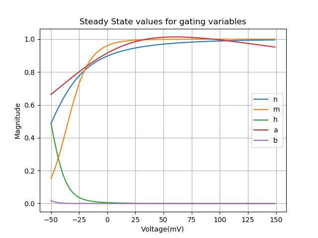

```python
t_e = 60 # ms
t_s = 600# ms
I_0 = np.arange(5,20.5,0.5)
firing_rates = np.zeros(I_0.shape[0])

def create_rectangle_impulse(I):
    def rectangle_impulse(t):
        if((t < t_e) or (t_s <= t)):
            return 0
        if((t_e <= t < t_s)):
            return I
    return rectangle_impulse



def steady_state(V_0):
    time = np.arange(0,500,0.025)
    n = np.zeros(1)
    m = np.zeros(1)
    h = np.zeros(1)
    a = np.zeros(1)
    b = np.zeros(1)

    for t in time:
        n_old = n[0]
        delta_n = dn_dt(V_0,n_old)
        n_new = n_old + delta_t * delta_n
        n[0] = n_new


        m_old = m[0]
        delta_m = dm_dt(V_0, m_old)
        m_new = m_old + delta_t * delta_m
        m[0] = m_new

        h_old = h[0]
        delta_h = dh_dt(V_0, h_old)
        h_new = h_old + delta_t * delta_h
        h[0] = h_new

        a_old = a[0]
        delta_a = da_dt(V_0, a_old)
        a_new = a_old + delta_t * delta_a
        a[0] = a_new


        b_old = b[0]
        delta_b = db_dt(V_0, b_old)
        b_new = b_old + delta_t * delta_b
        b[0] = b_new


    return m[0],h[0],n[0],a[0],b[0]

# debugging
n_stat = np.zeros(200)
m_stat = np.zeros(200)
h_stat = np.zeros(200)
a_stat = np.zeros(200)
b_stat = np.zeros(200)

voltage = range(-50,150)
for i,v in enumerate(voltage):
    m_stat[i],h_stat[i],n_stat[i],a_stat[i],b_stat[i] = steady_state(v)


fig, ax = plt.subplots()
ax.plot(voltage, n_stat, label = "n")
ax.plot(voltage, m_stat, label = "m")
ax.plot(voltage, h_stat, label = "h")
ax.plot(voltage, a_stat, label = "a")
ax.plot(voltage, b_stat, label = "b")

ax.legend()
ax.set(xlabel='Voltage(mV)', ylabel='Magnitude',title='Steady State values for gating variables')

ax.grid()
plt.show()
```

```python
def approximate_a_type_model(V_0, input_function, duration, delta_t):
    m_0,h_0,n_0,a_0,b_0 = steady_state(V_0)
    steps = np.arange(0,duration,delta_t)


    V = np.zeros(steps.shape[0])
    m = np.zeros(steps.shape[0])
    h = np.zeros(steps.shape[0])
    n = np.zeros(steps.shape[0])
    a = np.zeros(steps.shape[0])
    b = np.zeros(steps.shape[0])

    V[0] = V_0
    m[0] = m_0
    h[0] = h_0
    n[0] = n_0
    a[0] = a_0
    b[0] = b_0


    for i,t in enumerate(steps[:-1]):

        V_old = V[i]
        m_old = m[i]
        h_old = h[i]
        n_old = n[i]
        a_old = a[i]
        b_old = b[i]

        m_new = m_old + delta_t * dm_dt(V_old,m_old)
        m[i+1] = m_new

        h_new = h_old + delta_t * dh_dt(V_old,h_old)
        h[i+1] = h_new

        n_new = n_old + delta_t * dn_dt(V_old,n_old)
        n[i+1] = n_new

        a_new = a_old + delta_t * da_dt(V_old,a_old)
        a[i+1] = a_new


        b_new = b_old + delta_t * db_dt(V_old,b_old)
        b[i+1] = b_new

        V_new = V_old + delta_t * dV_dt(V_old,input_function, m_old, h_old, n_old, a_old, b_old, t)
        V[i+1] = V_new


    return V,m,h,n,a,b,steps
```

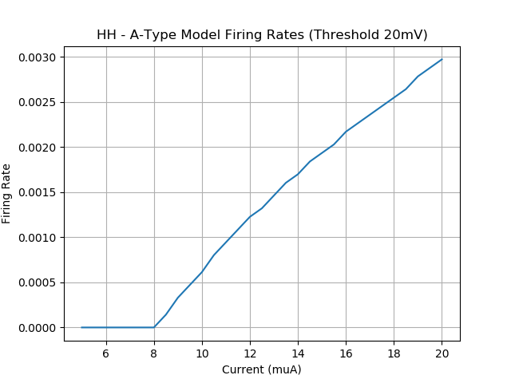

```python
def firing_rate(V):
    rate = 0
    for i,v in enumerate(V):
        if(v >= 20 and V[i-1]< 20):
            rate += 1

    return rate/len(V)

for i,I in enumerate(I_0):
    input_function = create_rectangle_impulse(I_0[i])

    V,m,h,n,a,b,steps = approximate_a_type_model(V_0, input_function, 1000, delta_t)
    start_measuring_time = t_e + 10
    start_index = int(start_measuring_time/delta_t)
    end_index = int(t_s/delta_t)

    firing_rates[i] = firing_rate(V[start_index:end_index])

fig, ax = plt.subplots()
ax.plot(I_0, firing_rates)

ax.set(xlabel='Current (muA)', ylabel='Firing Rate',
title='HH - A-Type Model Firing Rates (Threshold 20mV)')

ax.grid()
plt.show()
```